# Introducing Machine Learning

Jan-Philipp Kolb

03 May 2019

# [Modern Machine Learning Algorithms](https://elitedatascience.com/machine-learning-algorithms)

Categorizing machine learning algorithms is tricky, and there are several reasonable approaches; they can be grouped into generative/discriminative, parametric/non-parametric, supervised/unsupervised, and so on.

# [Machine Learning - Components](https://www.linkedin.com/pulse/20140822073217-180198720-6-components-of-a-machine-learning-algorithm)

- Feature Extraction + Domain knowledge
- Feature Selection
- Choice of Algorithm

Naive Bayes, [Support Vector Machines](https://github.com/Japhilko/DataAnalysis/blob/master/Machine%20Learning/SupportVectorMachines.md), Decision Trees, k-Means Clustering, …

- Training
- Choice of Metrics/Evaluation Criteria
- Testing

# [Feature selection](https://en.wikipedia.org/wiki/Feature_selection)

# [Supervised vs unsupervised learning](https://towardsdatascience.com/supervised-vs-unsupervised-learning-14f68e32ea8d)

### Supervised Learning

- we have prior knowledge of what the output values for our samples should be.

# Task: Find R-packages

Go to https://cran.r-project.org/ and search for packages that,…

- can be used for lasso regression

# Task View Machine Learning

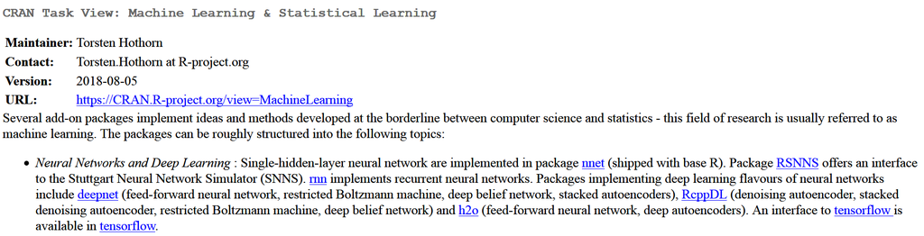

# Install all packages of a task view

```r
install.packages("ctv")
ctv::install.views("MachineLearning")
```

# [Prediction vs. Causation in Regression Analysis](https://statisticalhorizons.com/prediction-vs-causation-in-regression-analysis)

# Literature for machine learning

[figure not shown]

# Introduction to machine learning with R

- [Your First Machine Learning Project in R Step-By-Step](https://machinelearningmastery.com/machine-learning-in-r-step-by-step/)
- chapter about machine learning in [awesome R](https://awesome-r.com/)
- [Shiny App for machine learning](https://www.showmeshiny.com/machlearn/)

# [The Curse of Dimensionality](https://elitedatascience.com/dimensionality-reduction-algorithms)

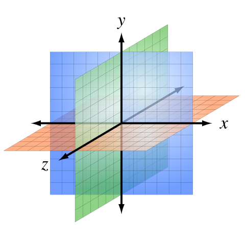

# Links

- [Presentations on ‘Elements of Neural Networks & Deep Learning’](https://www.r-bloggers.com/my-presentations-on-elements-of-neural-networks-deep-learning-parts-45/)
- [Understanding the Magic of Neural Networks](https://www.r-bloggers.com/understanding-the-magic-of-neural-networks/)
- [Neural Text Modelling with R package ruimtehol](https://www.r-bloggers.com/neural-text-modelling-with-r-package-ruimtehol/)
- [Feature Selection using Genetic Algorithms in R](https://www.r-bloggers.com/feature-selection-using-genetic-algorithms-in-r/)
- [Lecture slides: Real-World Data Science (Fraud Detection, Customer Churn & Predictive Maintenance)](https://www.r-bloggers.com/lecture-slides-real-world-data-science-fraud-detection-customer-churn-predictive-maintenance/)
- [Automated Dashboard for Credit Modelling with Decision trees and Random forests in R](https://www.r-bloggers.com/automated-dashboard-for-credit-modelling-with-decision-trees-and-random-forests-in-r/)
- [Looking Back at Google’s Research Efforts in 2018](https://ai.googleblog.com/2019/01/looking-back-at-googles-research.html)
- [Selecting ‘special’ photos on your phone](https://www.r-bloggers.com/selecting-special-photos-on-your-phone/)
- [Open Source AI, ML & Data Science News](https://www.r-bloggers.com/ai-machine-learning-and-data-science-roundup-january-2019/)
- Google`s [Machine Learning Crash Course](https://developers.google.com/machine-learning/crash-course/)
- [A prelude to machine learning](https://eight2late.wordpress.com/2017/02/23/a-prelude-to-machine-learning/)
- [caret webinar by Max Kuhn - on youtube](https://www.youtube.com/watch?v=7Jbb2ItbTC4)
- learn-math-for-data-science
- learn-statistics-for-data-science
- machine-learning-projects-for-beginners
- [An Introduction to machine learning](http://www-bcf.usc.edu/~gareth/ISL/)
- [ISLR book](http://www-bcf.usc.edu/~gareth/ISL/ISLR%20Seventh%20Printing.pdf)